### Analyzing the Stroop Effect

Perform the analysis in the space below. Remember to follow [the instructions](https://docs.google.com/document/d/1-OkpZLjG_kX9J6LIQ5IltsqMzVWjh36QpnP2RYpVdPU/pub?embedded=True) and review the [project rubric](https://review.udacity.com/#!/rubrics/71/view) before submitting. Once you've completed the analysis and write up, download this file as a PDF or HTML file and submit in the final section of this lesson.

# Analyzing the Stroop Effect

In a Stroop task, participants are presented with a list of words, with each word displayed in a color of ink. The participant’s task is to say out loud the color of the ink in which the word is printed. The task has two conditions: a congruent words condition, and an incongruent words condition. In the congruent words condition, the words being displayed are color words whose names match the colors in which they are printed. In the incongruent words condition, the words displayed are color words whose names do not match the colors in which they are printed. In each case, we measure the time it takes to name the ink colors in equally-sized lists. Each participant will go through and record a time from each condition.

# Questions

##### (1) What is the independent variable? What is the dependent variable?

There are two independent variables in this experiment: the congruent and incongruent words. The dependent variable is an outcome of the experiment by manipulating those dependent variables, and it is the time it takes to name the ink colors.

Therefore, the congruent and incongruent words are independent variables while the time it takes to name the ink colors is the dependent variable.

(2) What is an appropriate set of hypotheses for this task? Specify your null and alternative hypotheses, and clearly define any notation used. Justify your choices.

Lets define two variables for hypothesis testing.

$\mu_{c}:$ mean reaction time for naming congruent words and  
$\mu_{ic}:$ mean reaction time for naming incongruent words;

Hypotheses to test:  
Null Hypothesis where $(H_{O}): \mu_{c}=\mu_{ic}$  
The mean reaction time to name the colors is the same for congruent and incongruent words.

While the alternate Hypothesis is $(H_{A}): \mu_{c}$ $\neq$ $\mu_{ic}$  
The mean reaction time to name the colors is different for congruent and incongruent words.

(3) Report some descriptive statistics regarding this dataset. Include at least one measure of central tendency and at least one measure of variability. The name of the data file is 'stroopdata.csv'.

Let us load the dataset with in Jupyter notebook by importing few packages for analysis and visualization.

```python
from __future__ import division
import pandas as pd
import numpy as np
import seaborn as sns
import matplotlib.pyplot as plt
from scipy import stats
%matplotlib inline
```

```python
stroop = pd.read_csv("stroopdata.csv")
stroop.head()
```

|  | Congruent | Incongruent |
| --- | --- | --- |
| 0 | 12.079 | 19.278 |
| 1 | 16.791 | 18.741 |
| 2 | 9.564 | 21.214 |
| 3 | 8.630 | 15.687 |
| 4 | 14.669 | 22.803 |

```python
stroop['Congruent'].describe()
```

```
count    24.000000
mean     14.051125
std       3.559358
min       8.630000
25%      11.895250
50%      14.356500
75%      16.200750
max      22.328000
Name: Congruent, dtype: float64
```

```python
stroop['Incongruent'].describe()
```

```
count    24.000000
mean     22.015917
std       4.797057
min      15.687000
25%      18.716750
50%      21.017500
75%      24.051500
max      35.255000
Name: Incongruent, dtype: float64
```

```python
round(stroop['Congruent'].describe()[6] - stroop['Congruent'].describe()[4],4)
```

```
4.3055
```

```python
round(stroop['Incongruent'].describe()[6] - stroop['Incongruent'].describe()[4],4)
```

```
5.3347
```

3.1. The Means are: (Congruent, Incongruent)= (14.0511, 22.0159)

3.2. The standarad deviations are : (Congruent, Incongruent)= (3.5594, 4.7971)

3.4 The interquantile range are: (Congruent, Incongruent)= (4.3055, 5.3347)

(4) Provide one or two visualizations that show the distribution of the sample data. Write one or two sentences noting what you observe about the plot or plots.

Please see below a boxplot and a density plots which show the distribution of data from both congruent and incongruent conditions.

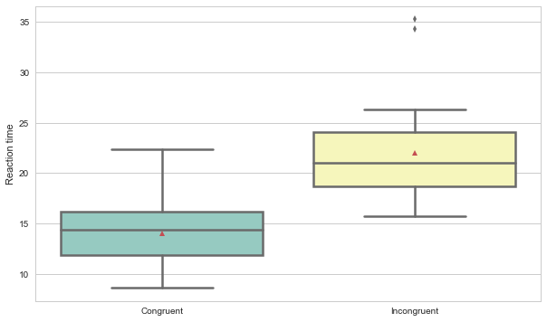

```python
sns.set(rc={'figure.figsize':(10,6)});
sns.set_style("whitegrid")
sns.boxplot(data=stroop, linewidth=2.5, palette="Set3", showmeans=True);
plt.ylabel('Reaction time');
```

From the box plot, we can see that the central tendency of the reaction time to name the colors in congruent words is less than that of incongruent words. The two points that lie out of the maximum value of the box plot in the incongruent data are clear outliers. Consequently, these points clearly pull up the mean of the incongruent data above the median as shown by a red dot. One of the assumptions for paired t-test is a normal distribution, however, in a real life, data are not perfectly normal and this distribution is nearly normal and the test is still applicable.

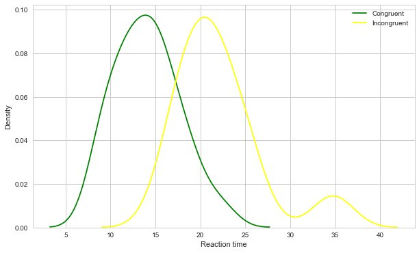

```python
sns.set(rc={'figure.figsize':(10,6)});
sns.set_style("whitegrid")
sns.distplot(stroop['Congruent'],hist=False, label='Congruent', color='green');
sns.distplot(stroop['Incongruent'],hist=False,label='Incongruent',color='yellow');
plt.xlabel('Reaction time');
plt.ylabel('Density');
```

Consistant with the boxplot, the kenal density plots also show that the mean central tendency of the reaction time to name the colors in congruent words is less than that of incongruent words.

(5) Now, perform the statistical test and report your results. What is your confidence level or Type I error associated with your test? What is your conclusion regarding the hypotheses you set up? Did the results match up with your expectations? **Hint:** Think about what is being measured on each individual, and what statistic best captures how an individual reacts in each environment.

The appropriate set of hypotheses for this experiment are:  
(1) $H_{O}$ : $\mu_{c}$= $\mu_{ic}$  
The poulation mean reaction time is the same for congruent and incongruent words.

(2) $H_{A}$ : $\mu_{c}$ $\neq$ $\mu_{ic}$  
The poulation mean reaction time is different for congruent and incongruent words.

Where $\mu_{c}$ and $\mu_{ic}$ are the population mean reaction time for congruent and incongruent words.

The mathematical expression for paired-sample t-test is carried out as:

$ t={\frac {{\bar {d}}}{\bar s_{p}{\sqrt {\frac {1}{n}}}}}$

Where ${\bar {d}}$, and ${\bar {s_{p}}}$ and $n$ are the mean, the standard deviation of the difference of the two indpendent variables and the sample size of the experiment, respectively.

```python
d_bar=(stroop['Incongruent'] - stroop['Congruent']).mean()
d_bar
```

```
7.964791666666667
```

```python
s_p=(stroop['Incongruent'] - stroop['Congruent']).std()
s_p
```

```
4.864826910359056
```

```python
t=d_bar/s_p*np.sqrt(24)

print "The t_value is %4.4f" % t
```

```
The t_value is 8.0207
```

```python
#Get the t-critical value for a 99.7% confidence level with sample size 24 (len(stroop)).
print "The critical t-value is %4.4f" % stats.t.ppf(0.997, len(stroop)-1)
```

```
The critical t-value is 3.0268
```

```python
#Get the t-critical value for a 99.7% confidence level with sample size 24 (len(stroop)).
print "The critical t-value is %4.4f" % stats.t.ppf(.997, len(stroop) - 1)
```

```
The critical t-value is 3.0268
```

(6) Optional: What do you think is responsible for the effects observed? Can you think of an alternative or similar task that would result in a similar effect? Some research about the problem will be helpful for thinking about these two questions!

The reaction time might be affected by individual difference since participants have different speed of reading and perceiving colors. It is harder for me as well preprocessing word and color simultaneously. There is always a loss of attention when you are presented two different informations with the same meaning simultaneously compared to two different infomation with two different meaning.